# LAGFF 2018

Nicholas Wisniewski

June 10, 2018

# Results

We ranked 3 TYPEs of films: Documentary (DOC), Feature (FEA), and Short (SHO); each is shown in a different color. The average vote is shown in the column labeled AVG, The number of total votes is shown in the column labeled VOTES. The authority score is shown in the column labeled AUTHORITY, and is used to determine the ranking. Note: the rankings within a subgroup of films may be slightly different than the order in the overall rankings (see algorithm).

## Overall

Overall Rankings

|  | FILM | TYPE | VOTES | AVG | DEGREE | AUTHORITY |
| --- | --- | --- | --- | --- | --- | --- |
| 1 | 1968 | DOC | 275 | 4.793 | 39.586 | 1.000 |
| 2 | THE LAST PARTISAN | DOC | 21 | 4.810 | 39.660 | 1.000 |
| 3 | THE LAST NOTE | FEA | 67 | 4.746 | 38.381 | 0.993 |
| 4 | JAMAICA | FEA | 129 | 4.721 | 37.737 | 0.990 |
| 5 | A FINE LINE | DOC | 28 | 4.679 | 37.004 | 0.984 |
| 6 | DOLPHIN MAN | DOC | 62 | 4.597 | 35.422 | 0.972 |
| 7 | KALINIXTA | SHO | 5 | 4.600 | 35.346 | 0.959 |
| 8 | ROSEMARIE | FEA | 19 | 4.526 | 34.135 | 0.953 |
| 9 | SMUGGLING HENDRIX | FEA | 259 | 4.440 | 32.698 | 0.940 |
| 10 | TOO MUCH INFO CLOUDING OVER MY HEAD | FEA | 48 | 4.312 | 29.549 | 0.885 |
| 11 | GOLDEN DAWN GIRLS | DOC | 58 | 4.310 | 29.515 | 0.883 |
| 12 | STILL | SHO | 40 | 4.300 | 29.207 | 0.877 |
| 13 | POLYXENI | FEA | 47 | 4.277 | 28.757 | 0.871 |
| 14 | DANCE FIGHT LOVE DIE | DOC | 30 | 4.233 | 27.610 | 0.841 |
| 15 | OURANIA | SHO | 43 | 4.186 | 26.584 | 0.825 |
| 16 | HAPPY BIRTHDAY | FEA | 36 | 4.167 | 26.088 | 0.814 |
| 17 | MANEKI NEKO | SHO | 28 | 4.143 | 25.543 | 0.797 |
| 18 | GOLDFISH | SHO | 40 | 4.050 | 23.202 | 0.749 |
| 19 | MUTE CITY | SHO | 22 | 3.955 | 21.176 | 0.685 |
| 20 | COWBOY | SHO | 48 | 3.917 | 20.207 | 0.671 |
| 21 | TESTING GRETA | SHO | 38 | 3.921 | 20.233 | 0.669 |
| 22 | THISSION CINEMA | DOC | 25 | 3.920 | 20.279 | 0.667 |
| 23 | HEARTS FOR DINNER | SHO | 30 | 3.867 | 19.019 | 0.636 |
| 24 | GO FOR BROKE | SHO | 40 | 3.750 | 16.219 | 0.554 |
| 25 | THORN | FEA | 8 | 3.750 | 16.345 | 0.545 |
| 26 | ICEBERGS | SHO | 55 | 3.709 | 15.306 | 0.529 |
| 27 | 9 TO 5 | SHO | 56 | 3.696 | 14.997 | 0.519 |
| 28 | 6:00 PM | SHO | 58 | 3.690 | 14.784 | 0.510 |
| 29 | DO IT YOURSELF | SHO | 34 | 3.647 | 13.955 | 0.483 |
| 30 | EUROPE | DOC | 13 | 3.538 | 12.025 | 0.414 |
| 31 | TICKET | SHO | 40 | 3.550 | 11.582 | 0.410 |
| 32 | BRAZUCA | SHO | 32 | 3.531 | 11.233 | 0.398 |
| 33 | HUMPHREY | SHO | 25 | 3.520 | 11.174 | 0.394 |
| 34 | ESCAPE | SHO | 60 | 3.483 | 10.163 | 0.364 |
| 35 | A BUDDY ALREADY DEAD | SHO | 37 | 3.378 | 8.060 | 0.293 |
| 36 | MIDNIGHT SHIFT | SHO | 56 | 3.304 | 6.731 | 0.247 |
| 37 | THE ROOSTERS CAGE | SHO | 58 | 3.293 | 6.625 | 0.243 |
| 38 | 8TH CONTINENT | SHO | 8 | 3.000 | 4.030 | 0.146 |
| 39 | LOVE ME NOT | FEA | 19 | 3.000 | 3.683 | 0.135 |
| 40 | ARIA | SHO | 38 | 2.947 | 2.476 | 0.093 |
| 41 | HIWA | SHO | 54 | 2.889 | 1.971 | 0.074 |
| 42 | COPA LOCA | SHO | 29 | 2.793 | 1.537 | 0.058 |

## Feature Films

Feature Film Rankings

|  | FILM | TYPE | VOTES | AVG | DEGREE | AUTHORITY |
| --- | --- | --- | --- | --- | --- | --- |
| 1 | THE LAST NOTE | FEA | 67 | 4.746 | 38.381 | 1.000 |
| 2 | JAMAICA | FEA | 129 | 4.721 | 37.737 | 0.989 |
| 3 | ROSEMARIE | FEA | 19 | 4.526 | 34.135 | 0.850 |
| 4 | SMUGGLING HENDRIX | FEA | 259 | 4.440 | 32.698 | 0.796 |
| 5 | TOO MUCH INFO CLOUDING OVER MY HEAD | FEA | 48 | 4.312 | 29.549 | 0.600 |
| 6 | POLYXENI | FEA | 47 | 4.277 | 28.757 | 0.551 |
| 7 | HAPPY BIRTHDAY | FEA | 36 | 4.167 | 26.088 | 0.429 |
| 8 | THORN | FEA | 8 | 3.750 | 16.345 | 0.224 |
| 9 | LOVE ME NOT | FEA | 19 | 3.000 | 3.683 | 0.010 |

## Documentaries

Documentary Rankings

|  | FILM | TYPE | VOTES | AVG | DEGREE | AUTHORITY |
| --- | --- | --- | --- | --- | --- | --- |
| 1 | THE LAST PARTISAN | DOC | 21 | 4.810 | 39.660 | 1.000 |
| 2 | 1968 | DOC | 275 | 4.793 | 39.586 | 0.999 |
| 3 | A FINE LINE | DOC | 28 | 4.679 | 37.004 | 0.885 |
| 4 | DOLPHIN MAN | DOC | 62 | 4.597 | 35.422 | 0.806 |
| 5 | GOLDEN DAWN GIRLS | DOC | 58 | 4.310 | 29.515 | 0.533 |
| 6 | DANCE FIGHT LOVE DIE | DOC | 30 | 4.233 | 27.610 | 0.468 |
| 7 | THISSION CINEMA | DOC | 25 | 3.920 | 20.279 | 0.221 |
| 8 | EUROPE | DOC | 13 | 3.538 | 12.025 | 0.048 |

## Shorts

Short Film Rankings

|  | FILM | TYPE | VOTES | AVG | DEGREE | AUTHORITY |
| --- | --- | --- | --- | --- | --- | --- |
| 1 | KALINIXTA | SHO | 5 | 4.600 | 35.346 | 1.000 |
| 2 | STILL | SHO | 40 | 4.300 | 29.207 | 0.981 |
| 3 | OURANIA | SHO | 43 | 4.186 | 26.584 | 0.957 |
| 4 | MANEKI NEKO | SHO | 28 | 4.143 | 25.543 | 0.933 |
| 5 | GOLDFISH | SHO | 40 | 4.050 | 23.202 | 0.910 |
| 6 | COWBOY | SHO | 48 | 3.917 | 20.207 | 0.842 |
| 7 | MUTE CITY | SHO | 22 | 3.955 | 21.176 | 0.836 |
| 8 | TESTING GRETA | SHO | 38 | 3.921 | 20.233 | 0.835 |
| 9 | HEARTS FOR DINNER | SHO | 30 | 3.867 | 19.019 | 0.803 |
| 10 | GO FOR BROKE | SHO | 40 | 3.750 | 16.219 | 0.716 |
| 11 | ICEBERGS | SHO | 55 | 3.709 | 15.306 | 0.693 |
| 12 | 9 TO 5 | SHO | 56 | 3.696 | 14.997 | 0.680 |
| 13 | 6:00 PM | SHO | 58 | 3.690 | 14.784 | 0.666 |
| 14 | DO IT YOURSELF | SHO | 34 | 3.647 | 13.955 | 0.631 |
| 15 | TICKET | SHO | 40 | 3.550 | 11.582 | 0.546 |
| 16 | BRAZUCA | SHO | 32 | 3.531 | 11.233 | 0.531 |
| 17 | HUMPHREY | SHO | 25 | 3.520 | 11.174 | 0.523 |
| 18 | ESCAPE | SHO | 60 | 3.483 | 10.163 | 0.488 |
| 19 | A BUDDY ALREADY DEAD | SHO | 37 | 3.378 | 8.060 | 0.396 |
| 20 | MIDNIGHT SHIFT | SHO | 56 | 3.304 | 6.731 | 0.335 |
| 21 | THE ROOSTERS CAGE | SHO | 58 | 3.293 | 6.625 | 0.329 |
| 22 | 8TH CONTINENT | SHO | 8 | 3.000 | 4.030 | 0.193 |
| 23 | ARIA | SHO | 38 | 2.947 | 2.476 | 0.126 |
| 24 | HIWA | SHO | 54 | 2.889 | 1.971 | 0.099 |
| 25 | COPA LOCA | SHO | 29 | 2.793 | 1.537 | 0.075 |

# Visualization

We visualized the ranking system using a forest plot. The average vote is depicted by a square and a 95% confidence interval. The number of total votes is depicted by the size of the squares. The authority score is used to determine the ranking

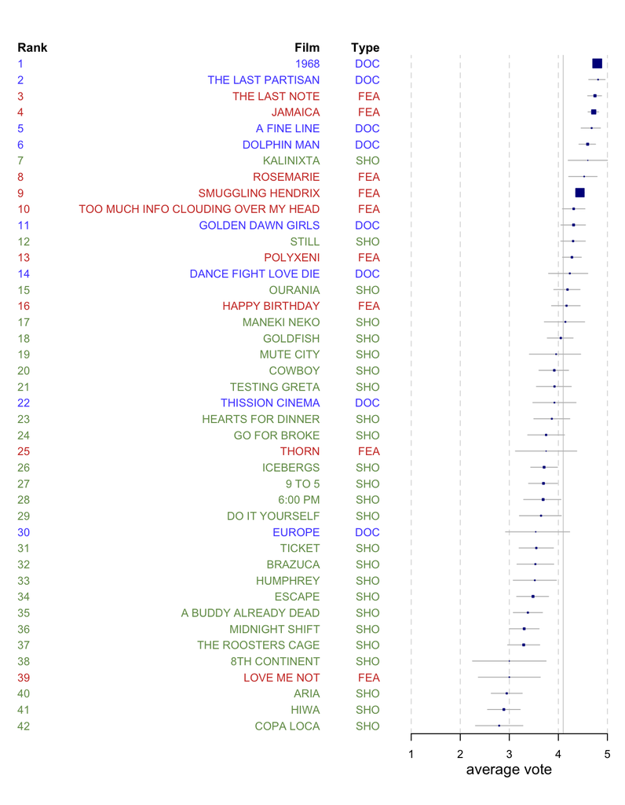

# About the Ranking Algorithm

The LAGFF ranking algorithm bootstraps the probability that the average score $\mu_i$ of film $i$ is truly greater than any other film $j$, by resampling the votes to simulate the universe of all possible rankings. This matrix of probabilities $p_{ij}=p(\mu_j \gt \mu_i)$ is then treated as a weighted directed graph, and the [authority score](http://citeseerx.ist.psu.edu/viewdoc/summary?doi=10.1.1.418.3908) $\text{eig}_1(p^Tp)$ is used to rank the films, in a way similar to Google *page-rank*.

### Why this algorithm?

This ranking system was adopted by LAGFF to address a problem in estimating ranks introduced by the wide range of audience sizes at a film festival. Specifically, ranking based on naive ordering the mean scores can produce undesirable results. For example, a high scoring film that many people came to see (opening/closing night) can sometimes be beaten by a film that very few people came to see, but which also scored highly, only because of the increased sampling error in the small group. The LAGFF algorithm addresses this problem by using resampling to weigh the relative superiority of each film to every other, which can then produce more meaningful rankings using graph theory.

### How are the results different?

This method is asymptotically equivalent to the naive ordering – in the limit where all audience sizes are large, they give the same results. However, when both large and small audiences are present, this method tends to favor scores from larger audiences, which is desirable.

# References

[[1](http://citeseerx.ist.psu.edu/viewdoc/summary?doi=10.1.1.418.3908)] Kleinberg, J. M. (1999). Authoritative sources in a hyperlinked environment. *Journal of the ACM (JACM)*, 46(5), 604-632.